# CAOS-10 exec

## Reminder

Мы все помним, что в Linux процессы выстраиваются в дерево

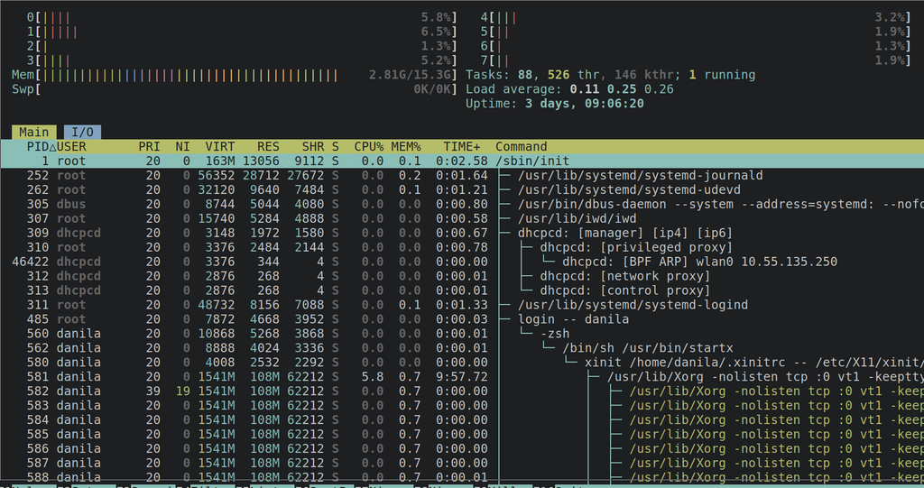

Так же мы помним, что **fork** - единственный (**clone** не считается) способ создать новый процесс в Linux

Более того, дочерний процесс будет копией родительского

Внимание вопрос: А как выполнить что-то другое?))

Давайте вспомним, что из себя представляет процесс

Процесс - программа в состоянии выполнения. Он включает в себя:

1. Исполняемый код (section .text)
2. Открытые файлы
3. Сигналы, ожидающие обработки
4. Внутренние данные ядра
5. Состояние процессора (регистры)
6. Адресное пространство, в которое отображены один или несколько файлов (mmap)
7. Один или несколько потоков выполнения (на самом деле это стек)
8. Сегмент данных с глобальными переменными (section .data / .rodata / .bss)

Ну и кажется нам нужно как-то подменить хотяб исполняемый код)

Мы (как процесс) не имеем прав на запись в секции .text

Но как же классно, что ядро все сделало за нас!))

## Exec

Exec - системный вызов, который подменяет наш контекст исполнения на другой

Что именно он нам подменит:

1. Исполняемый код (section .text) **да - заменит на новый**
2. Открытые файлы **нет**
3. Сигналы, ожидающие обработки **нет**
4. Внутренние данные ядра **частично**
5. Состояние процессора (регистры) **да**
6. Адресное пространство, в которое отображены один или несколько файлов (mmap) **да - все сбросится**
7. Один или несколько потоков выполнения (на самом деле это стек) **да - у нас будет новый стек**
8. Сегмент данных с глобальными переменными (section .data / .rodata / .bss) **да**

Нам тут интересны пункты **1,6,7,8** и **2**

**1,6,7,8** говорят нам о том, что внутренности нашей программы заменятся на новые

**2** говорит о том, что мы сохраняем открытые файлы (и, в частности наследуем **stdin**, **stdout**, **stderr**)

Есть вопросы про **идею** exec?

## По теории все, погнали смотреть на примеры!

### man 3 exec

exec принмает путь до **elf** файла и аргументы командной строки

```
NAME
       execl, execlp, execle, execv, execvp, execvpe - execute a file

LIBRARY
       Standard C library (libc, -lc)

SYNOPSIS
       #include <unistd.h>

       extern char **environ;

       int execl(const char *pathname, const char *arg, ...
                       /*, (char *) NULL */);
       int execlp(const char *file, const char *arg, ...
                       /*, (char *) NULL */);
       int execle(const char *pathname, const char *arg, ...
                       /*, (char *) NULL, char *const envp[] */);
       int execv(const char *pathname, char *const argv[]);
       int execvp(const char *file, char *const argv[]);
       int execvpe(const char *file, char *const argv[], char *const envp[]);
```

Сори, jupyter будет материться(((

[figure not shown]

### Simple-1 ls

Хотим запустить *ls* в текущей директории

Подключаем все необходимое

```python
#include <unistd.h>
#include <stdio.h>
```

```
[danila@archlinux ~/caos/09-fork]
$ whereis ls
ls: /usr/bin/ls /usr/share/man/man1/ls.1.gz /usr/share/man/man1p/ls.1p.gz
```

```python
{
    pid_t pid = fork();

    if (pid == 0) {
        execlp("ls", "bla bla bla", "-la", NULL);  // аргументы команды = аргументы ф-ии
    }
}
```

```
total 832
drwxr-xr-x 3 danila danila   4096 Nov 10 01:14 .
drwxr-xr-x 7 danila danila   4096 Nov  8 20:47 ..
drwxr-xr-x 2 danila danila   4096 Nov 10 00:03 .ipynb_checkpoints
-rw-r--r-- 1 danila danila 720143 Nov 10 01:14 main.ipynb
-rw-r--r-- 1 danila danila 118022 Nov 10 00:33 wmeme.webp
```

```python
{
    pid_t pid = fork();

    if (pid == 0) {
        char *const my_argv[] = { "why am i working???", "-1", NULL };  // аргументы команды = массивчик
        execvp("ls", my_argv);
    }
}
```

[output not shown]

```
main.ipynb
wmeme.webp
```

```python
{
    pid_t pid = fork();

    if (pid == 0) {
        execl("ls", "kill me please!!!", NULL); // ничего не работает))) (потому что нет `p`)
        _exit(1);
    }
}
```

```
[danila@archlinux ~/caos/10-exec]
$ echo $PATH
/usr/local/sbin:/usr/local/bin:/usr/bin:/usr/bin/site_perl:/usr/bin/vendor_perl:/usr/bin/core_perl
```

Вопросы?))

(нет, вам не обязательно обарачивать все в {})

У меня тоже есть вопрос))

А почему эта фигня работает???

```python
{
    pid_t pid = fork();

    if (pid == 0) {
        execlp("ls", "bla bla bla", "-la", NULL);  // аргументы команды = аргументы ф-ии
    }
}
```

```
total 832
drwxr-xr-x 3 danila danila   4096 Nov 10 01:14 .
drwxr-xr-x 7 danila danila   4096 Nov  8 20:47 ..
drwxr-xr-x 2 danila danila   4096 Nov 10 00:03 .ipynb_checkpoints
-rw-r--r-- 1 danila danila 720143 Nov 10 01:14 main.ipynb
-rw-r--r-- 1 danila danila 118022 Nov 10 00:33 wmeme.webp
```

```
int main(int argc, char *argv[]) {
    // argv[0] = name of executable!!))
}
```

Запускаем ls правильнее))

```python
{
    pid_t pid = fork();

    if (pid == 0) {
        execlp("ls", "/usr/bin/ls", "-la", NULL);
    }
}
```

```
total 832
drwxr-xr-x 3 danila danila   4096 Nov 10 01:14 .
drwxr-xr-x 7 danila danila   4096 Nov  8 20:47 ..
drwxr-xr-x 2 danila danila   4096 Nov 10 00:03 .ipynb_checkpoints
-rw-r--r-- 1 danila danila 720143 Nov 10 01:14 main.ipynb
-rw-r--r-- 1 danila danila 118022 Nov 10 00:33 wmeme.webp
```

Так тоже правильно

```python
{
    pid_t pid = fork();

    if (pid == 0) {
        execlp("ls", "ls", "-la", NULL);
    }
}
```

```
total 832
drwxr-xr-x 3 danila danila   4096 Nov 10 01:14 .
drwxr-xr-x 7 danila danila   4096 Nov  8 20:47 ..
drwxr-xr-x 2 danila danila   4096 Nov 10 00:03 .ipynb_checkpoints
-rw-r--r-- 1 danila danila 720143 Nov 10 01:14 main.ipynb
-rw-r--r-- 1 danila danila 118022 Nov 10 00:33 wmeme.webp
```

Ну и на самом деле так тоже правильно))

```python
{
    pid_t pid = fork();

    if (pid == 0) {
        execlp("ls", "bla bla bla", "-la", NULL);
    }
}
```

```
total 832
drwxr-xr-x 3 danila danila   4096 Nov 10 01:14 .
drwxr-xr-x 7 danila danila   4096 Nov  8 20:47 ..
drwxr-xr-x 2 danila danila   4096 Nov 10 00:03 .ipynb_checkpoints
-rw-r--r-- 1 danila danila 720143 Nov 10 01:14 main.ipynb
-rw-r--r-- 1 danila danila 118022 Nov 10 00:33 wmeme.webp
```

### Simple-1.5 Обработка ошибок

**ЕСЛИ МЫ ВЕРНУЛИСЬ ИЗ EXEC, ЗНАЧИТ ОН НЕ ОТРАБОТАЛ**

```python
{
    pid_t pid = fork();

    if (pid == 0) {
        execl("some unexisting command", "lfadslfaldsf", NULL);

        perror("Exec failed :(\n\t");
        _exit(1);
    }
}
```

```
Exec failed :(
	: No such file or directory
```

### Simple-2 pipes NOT working

```python
{
    pid_t pid = fork();

    if (pid == 0) {
        execlp("seq", "seq", "5", NULL);
    }
}
```

```
1
2
3
4
5
```

```python
{
    pid_t pid = fork();

    if (pid == 0) {
        // seq 1 5 | wc
        execlp("seq", "seq", "5", "|", "wc", NULL);
    }
}
```

```
seq: invalid floating point argument: ‘|’
Try 'seq --help' for more information.
```

**Вопрос:** а почему не работает?)

### Simple-3 питончик)

```python
{
    pid_t pid = fork();

    if (pid == 0) {
        /* $ python3 -c '''
         * quote> import numpy as np
         * quote> print(np.arange(10))
         * quote> '''
         */
        execlp("python3", "python3", "-c",
               "import numpy as np\n" \
               "print(np.arange(10))"
               , NULL);
    }
}
```

```
[0 1 2 3 4 5 6 7 8 9]
```

### Simple-4 Совет (правильно используем execv*)

```python
void say_smth_and_exit(char *msg) {
    char *argv[] = { "echo", msg, NULL };
    execvp(argv[0], argv);
}
```

```
input_line_15:2:22: warning: ISO C++11 does not allow conversion from string literal to 'char *' [-Wwritable-strings]
    char *argv[] = { "echo", msg, NULL };
                     ^
```

```python
{
    pid_t pid = fork();

    if (pid == 0) {
        char msg[] = "Даня, проверь домашки!!!";
        say_smth_and_exit(msg);
    }
}
```

```
Даня, проверь домашки!!!
```